# First insights into the movement patterns of maned wolf with sarcoptic mange

### 2.3 Home range overlap

Once the home range outputs exist, overlap can be computed directly from the saved AKDE estimates.

The script reads the saved AKDE objects for each period, calculates overlap metrics and their confidence intervals, and writes one consolidated table.

**`03_overlap_ctmm.R: complete home range overlap workflow`**

```r
# Calculate seasonal home-range overlap between the female maned wolves.
# The exported table is used in Figure 1

# Load libraries
library(ctmm)
library(tidyverse)

# Load output data
akde_files <- list.files(
  "output/models/fit_akde",
  pattern = "list_akde_.*\\.rds$",
  full.names = TRUE
)

final_overlap_results <- akde_files |>
  map_dfr(
    \(file_path) {
      period_name <- stringr::str_extract(
        basename(file_path),
        "(?<=list_akde_).*(?=\\.rds)"
      )
      period_name <- stringr::str_replace(period_name, "Rainy", "Wet")

      if (stringr::str_detect(period_name, "Total$")) {
        return(tibble())
      }

      akde_list <- readRDS(file_path)

      if (inherits(akde_list[[1]], "list")) {
        akde_list <- purrr::list_flatten(akde_list)
      }

      # Skip periods with fewer than two focal animals because overlap cannot
      # be calculated for a single home range
      if (length(akde_list) < 2) {
        return(tibble())
      }

      overlap_res <- ctmm::overlap(akde_list)

      map_dfr(
        c("low", "est", "high"),
        \(ci_level) {
          ci_matrix <- overlap_res$CI[,, ci_level]
          upper_index <- which(
            upper.tri(ci_matrix, diag = FALSE),
            arr.ind = TRUE
          )

          tibble(
            animal_1 = rownames(ci_matrix)[upper_index[, 1]],
            animal_2 = colnames(ci_matrix)[upper_index[, 2]],
            value = ci_matrix[upper_index],
            ci_level = ci_level,
            period = period_name
          )
        }
      )
    }
  ) |>
  pivot_wider(names_from = ci_level, values_from = value) |>
  mutate(
    period = factor(
      period,
      levels = c(
        "2023_Wet",
        "2024_Dry",
        "2024_Wet"
      ),
      ordered = TRUE
    )
  ) |>
  arrange(period, animal_1, animal_2) |>
  mutate(period = as.character(period))

dir.create("output/tables/overlap", recursive = TRUE, showWarnings = FALSE)

final_overlap_results |>
  write_csv("output/tables/overlap/overlap_results_period_individuals.csv")
```

Home-range estimates, seasonal overlap, and monthly distance moved for the two focal females are summarized in Figure 1. Their annual home-range map and the associated land-cover composition are presented in Figure 2.

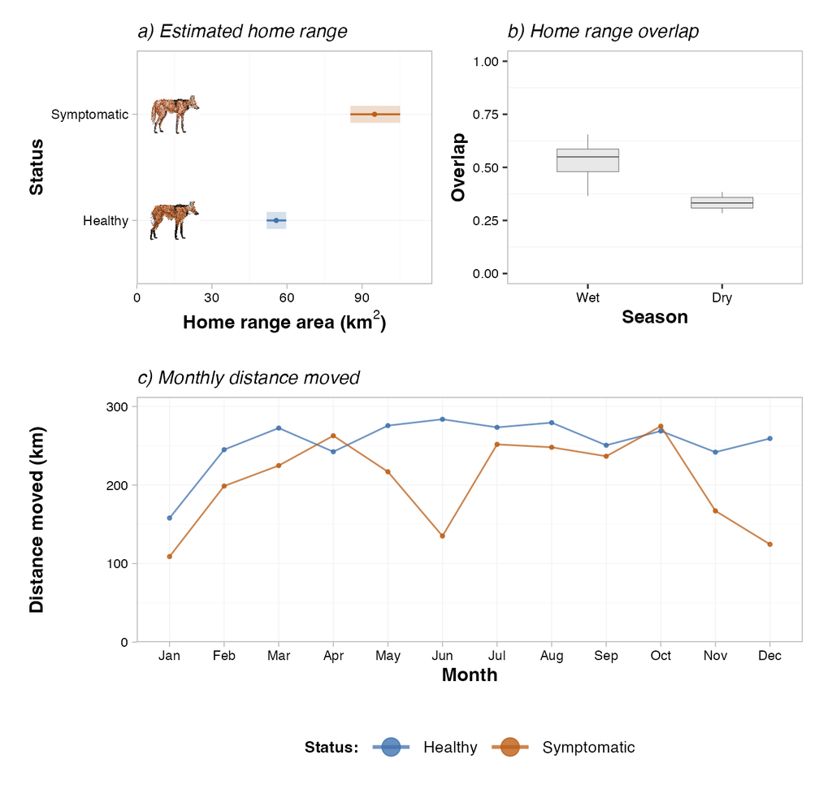

Figure 1: Home-range area, overlap, and monthly distance moved for the two focal females.

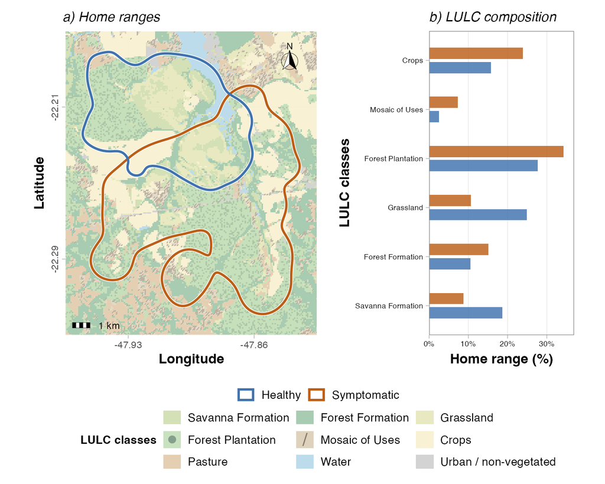

Figure 2: Annual home ranges and land-cover composition for the two focal females.

## 3 Time-Explicit Habitat Selection (TEHS) model

This is the most model-intensive section of the workflow because it moves from cleaned relocation data to step construction, habitat extraction, alternative-step generation, Bayesian model fitting, and posterior consolidation.

To keep this section readable, the workflow is broken into the same order used during the analysis: first derive step-level habitat information, then prepare the objects needed by JAGS, then fit the two model components, and finally translate the posterior results into the manuscript panel.

### 3.1 Extract land-cover proportions for each movement step

The TEHS section starts from the same cleaned GPS file used previously in the project, but it transforms consecutive relocations into movement steps rather than home range objects. It requires the MapBiomas LULC raster for São Paulo (2023; 10-m pixels), which is not versioned on GitHub because of its size. Before running scripts 04 and 05, download the raster from [MapBiomas](https://brasil.mapbiomas.org/en/) and save it as `data/raster/mapbiomas_10m_sp_2023-0000000000-0000000000.tif`. The complete script below then extracts MapBiomas classes for each buffered movement segment and summarizes the step-level habitat information used in the TEHS workflow.

**`04_lulc_prop_TEHS.R: complete step-level LULC workflow`**

```r
# Calculate step-level LULC proportions for maned wolf data

# Libraries ----
library(lubridate)
library(terra)
library(sf)
library(tidyverse)

options(scipen = 999) # avoid scientific notation
terra::terraOptions(progress = 0)

# Inputs and parameters ----
gps_path <- "data/processed/gps_no_outliers_final.csv"
raster_path <- "data/raster/mapbiomas_10m_sp_2023-0000000000-0000000000.tif"
output_dir <- "output/TEHS/mapbiomas"
raster_tag <- basename(raster_path) |> str_remove("\\.tif$")
focal_animals <- c("704870A", "704871A")

# Define parameters to be used in the code
buffer_m <- 30
speed_quantile <- 0.95
max_step_minutes <- 720
min_step_distance_m <- 1
min_lulc_use_prop <- 0.04

dir.create(output_dir, recursive = TRUE, showWarnings = FALSE)

if (!file.exists(raster_path)) {
  stop(
    "Missing MapBiomas LULC raster: ", raster_path,
    "\nDownload the 2023, 10-m LULC raster for São Paulo from ",
    "https://brasil.mapbiomas.org/en/ and save it at this path before running this script."
  )
}

# MapBiomas legend (Collection 10 - relevant classes) ----
lulc_legend <- tibble::tribble(
  ~class_code , ~class_name                  ,
   3L         , "Forest Formation"           ,
   4L         , "Savanna Formation"          ,
   5L         , "Mangrove"                   ,
   6L         , "Floodable Forest"           ,
   9L         , "Forest Plantation"          ,
  11L         , "Wetland"                    ,
  12L         , "Grassland"                  ,
  13L         , "Other Non Forest Formation" ,
  15L         , "Pasture"                    ,
  18L         , "Agriculture"                ,
  19L         , "Temporary Crops"            ,
  20L         , "Sugarcane"                  ,
  21L         , "Mosaic of Uses"             ,
  23L         , "Beach, Dune and Sand Spot"  ,
  24L         , "Urban Infrastructure"       ,
  25L         , "Other Non Vegetated Area"   ,
  26L         , "Water"                      ,
  29L         , "Rocky Outcrop"              ,
  30L         , "Mining"                     ,
  31L         , "Aquaculture"                ,
  33L         , "River, Lake and Ocean"      ,
  36L         , "Perennial Crops"            ,
  49L         , "Wooded Restinga"
)

# Read GPS data directly ----
# Read and standardize columns used in the workflow
gps <- read_csv(gps_path, show_col_types = FALSE) |>
  rename(individual = track) |>
  mutate(
    timestamp = ymd_hms(timestamp, tz = "UTC", quiet = TRUE),
  ) |>
  select(individual, timestamp, longitude, latitude) |>
  filter(
    individual %in% focal_animals,
    !is.na(individual),
    !is.na(timestamp),
    !is.na(longitude),
    !is.na(latitude)
  )

# Read raster directly ----
# Use the confirmed MapBiomas raster file without tile selection logic
mapbiomas_raster <- rast(raster_path)
lulc_col <- names(mapbiomas_raster)[1]

# Convert GPS to projected coordinates for movement metrics ----
# Keep original lon/lat and add projected x/y in meters
gps_sf <- gps |>
  st_as_sf(
    coords = c("longitude", "latitude"),
    crs = 4326,
    remove = FALSE
  ) |>
  st_transform(5880)

gps_coords <- st_coordinates(gps_sf)

# Add the columns 5880 to calulcate steps in meters
gps_5880 <- gps |>
  mutate(
    x_5880 = gps_coords[, 1],
    y_5880 = gps_coords[, 2]
  )

# Build movement steps ----
# Create start/end points and movement metrics for each individual
steps <- gps_5880 |>
  arrange(individual, timestamp) |>
  group_by(individual) |>
  mutate(
    x_sta = x_5880,
    y_sta = y_5880,
    x_end = lead(x_5880),
    y_end = lead(y_5880),
    time_sta = timestamp,
    time_end = lead(timestamp),
    time_min = as.numeric(difftime(time_end, time_sta, units = "mins")),
    dist_m = sqrt((x_end - x_sta)^2 + (y_end - y_sta)^2),
    speed_mps = dist_m / (time_min * 60),
    month_num = month(time_sta),
    calendar_year = year(time_sta),
    season_year = if_else(
      month_num <= 3,
      calendar_year - 1L,
      calendar_year
    ),
    season = if_else(month_num >= 10 | month_num <= 3, "Wet", "Dry"),
    period = paste(season_year, season, sep = "_")
  ) |>
  ungroup() |>
  filter(
    !is.na(x_end),
    !is.na(y_end),
    !is.na(time_min),
    time_min > 0,
    !is.na(dist_m),
    !is.na(speed_mps)
  ) |>
  mutate(
    dist_m = if_else(dist_m == 0, 1, dist_m)
  )

# Filter movement outliers ----
# Remove very fast movements and very long temporal gaps
speed_limits <- steps |>
  group_by(individual) |>
  summarise(
    speed_limit = quantile(speed_mps, speed_quantile, na.rm = TRUE),
    .groups = "drop"
  )

steps_filter <- steps |>
  left_join(speed_limits, by = "individual") |>
  filter(
    speed_mps <= speed_limit,
    time_min <= max_step_minutes,
    dist_m > min_step_distance_m
  ) |>
  select(-speed_limit)

if (nrow(steps_filter) == 0) {
  stop("All movement steps were removed by filters. Review thresholds.")
}

# Periods by year and season
period_levels <- steps_filter |>
  group_by(period) |>
  summarise(start_date = min(time_sta), .groups = "drop") |>
  arrange(start_date) |>
  pull(period)

steps_filter <- steps_filter |>
  mutate(
    step_id = row_number(),
    period = factor(period, levels = period_levels, ordered = TRUE)
  )

# Create line buffers for each step ----
# Each step is converted to a 30 m buffer polygon
step_lines_geom <- lapply(seq_len(nrow(steps_filter)), function(i) {
  st_linestring(
    matrix(
      c(
        steps_filter$x_sta[i],
        steps_filter$y_sta[i],
        steps_filter$x_end[i],
        steps_filter$y_end[i]
      ),
      ncol = 2,
      byrow = TRUE
    )
  )
})

# Create buffer
step_buffers <- st_sf(
  step_id = steps_filter$step_id,
  geometry = st_sfc(step_lines_geom, crs = 5880)
) |>
  st_buffer(dist = buffer_m)

step_buffers_vect <- vect(step_buffers)
if (!same.crs(mapbiomas_raster, step_buffers_vect)) {
  step_buffers_vect <- project(step_buffers_vect, mapbiomas_raster)
}

# Crop the raster once to the buffered step extent before extracting pixels
mapbiomas_crop <- terra::crop(
  mapbiomas_raster,
  terra::ext(step_buffers_vect),
  snap = "out"
)

# Extract raster classes inside each step buffer ----
# Keep only non-missing class codes
extracted <- terra::extract(
  mapbiomas_crop[[1]],
  step_buffers_vect,
  ID = TRUE
) |>
  as_tibble() |>
  rename(step_id = ID) |>
  mutate(
    class_code = as.integer(.data[[lulc_col]])
  ) |>
  select(step_id, class_code) |>
  filter(!is.na(class_code))

if (nrow(extracted) == 0) {
  stop("No LULC pixels were extracted from step buffers.")
}

# Recode classes for the analysis setup ----
# Merge Temporary and Perennial Crops
step_lulc <- extracted |>
  left_join(lulc_legend, by = "class_code") |>
  mutate(
    class_name = coalesce(class_name, paste0("Class ", class_code)),
    class_group = case_when(
      class_code %in% c(19L, 36L) ~ "Crops",
      TRUE ~ class_name
    )
  )

# Calculate per-step proportions in long format ----
step_lulc_counts <- step_lulc |>
  count(step_id, class_group, name = "n_pixels")

step_lulc_long_all <- step_lulc_counts |>
  group_by(step_id) |>
  mutate(prop_lulc = n_pixels / sum(n_pixels)) |>
  ungroup()

# Calculate overall usage and apply threshold ----
# Keep only classes above the minimum usage threshold
lulc_usage_overall <- step_lulc_counts |>
  group_by(class_group) |>
  summarise(n_pixels = sum(n_pixels), .groups = "drop") |>
  mutate(
    prop_use = n_pixels / sum(n_pixels),
    keep_class = prop_use >= min_lulc_use_prop
  ) |>
  arrange(desc(prop_use))

kept_groups <- lulc_usage_overall |>
  filter(keep_class) |>
  pull(class_group)

if (length(kept_groups) == 0) {
  stop(
    "No LULC class reached the threshold of ",
    scales::percent(min_lulc_use_prop, accuracy = 0.1),
    "."
  )
}

step_lulc_long <- step_lulc_long_all |>
  filter(class_group %in% kept_groups)

# Build column names for wide output ----
# Convert class labels into safe snake_case column names
lulc_columns <- lulc_usage_overall |>
  filter(keep_class) |>
  mutate(
    lulc_col = paste0(
      "lulc_",
      gsub(
        "_+",
        "_",
        gsub(
          "^_|_$",
          "",
          gsub(
            "[^a-z0-9]+",
            "_",
            tolower(iconv(class_group, to = "ASCII//TRANSLIT"))
          )
        )
      )
    )
  ) |>
  select(class_group, lulc_col)

# Create final step-level dataset (wide format) ----
# One row per step with one column per kept class
step_lulc_wide <- step_lulc_long |>
  left_join(lulc_columns, by = "class_group") |>
  select(step_id, lulc_col, prop_lulc) |>
  pivot_wider(
    names_from = lulc_col,
    values_from = prop_lulc,
    values_fill = 0
  )

final_database <- steps_filter |>
  left_join(step_lulc_wide, by = "step_id") |>
  arrange(individual, time_sta)

lulc_col_names <- lulc_columns$lulc_col
if (length(lulc_col_names) > 0) {
  final_database <- final_database |>
    mutate(
      across(all_of(lulc_col_names), ~ replace_na(.x, 0))
    )
}

# Save only the files consumed by the next TEHS preparation step
write_csv(
  final_database,
  file.path(output_dir, str_glue("step_lulc_prop_common_{raster_tag}.csv"))
)

write_csv(
  lulc_usage_overall,
  file.path(
    output_dir,
    str_glue("step_lulc_overall_use_threshold_{raster_tag}.csv")
  )
)

write_csv(
  lulc_columns,
  file.path(output_dir, str_glue("step_lulc_columns_kept_{raster_tag}.csv"))
)

cat(
  "LULC step extraction finished.\n",
  "Output dir: ",
  output_dir,
  "\n",
  "Threshold: ",
  scales::percent(min_lulc_use_prop, accuracy = 0.1),
  "\n",
  "Groups kept: ",
  paste(kept_groups, collapse = ", "),
  "\n",
  sep = ""
)
```